# Risk Factor Analysis

## Outcome Variable

**Outcome Variable:** ever_co

## Predictor Variables

**Intervention Variable:** sex

**Adjustment Set:**

unadjusted

## Stratifying Variables

The analysis was stratified on these variable(s):

- agecat
- studyid
- country

## Data Summary

| agecat | studyid | country | sex | ever_co | n_cell | n |
| --- | --- | --- | --- | --- | --- | --- |
| 0-24 months | CMC-V-BCS-2002 | INDIA | Female | 0 | 157 | 373 |
| 0-24 months | CMC-V-BCS-2002 | INDIA | Female | 1 | 30 | 373 |
| 0-24 months | CMC-V-BCS-2002 | INDIA | Male | 0 | 130 | 373 |
| 0-24 months | CMC-V-BCS-2002 | INDIA | Male | 1 | 56 | 373 |
| 0-24 months | CMIN | BANGLADESH | Female | 0 | 76 | 271 |
| 0-24 months | CMIN | BANGLADESH | Female | 1 | 42 | 271 |
| 0-24 months | CMIN | BANGLADESH | Male | 0 | 103 | 271 |
| 0-24 months | CMIN | BANGLADESH | Male | 1 | 50 | 271 |
| 0-24 months | COHORTS | GUATEMALA | Female | 0 | 579 | 1349 |
| 0-24 months | COHORTS | GUATEMALA | Female | 1 | 56 | 1349 |
| 0-24 months | COHORTS | GUATEMALA | Male | 0 | 621 | 1349 |
| 0-24 months | COHORTS | GUATEMALA | Male | 1 | 93 | 1349 |
| 0-24 months | COHORTS | INDIA | Female | 0 | 3278 | 7402 |
| 0-24 months | COHORTS | INDIA | Female | 1 | 271 | 7402 |
| 0-24 months | COHORTS | INDIA | Male | 0 | 3462 | 7402 |
| 0-24 months | COHORTS | INDIA | Male | 1 | 391 | 7402 |
| 0-24 months | COHORTS | PHILIPPINES | Female | 0 | 1190 | 3045 |
| 0-24 months | COHORTS | PHILIPPINES | Female | 1 | 241 | 3045 |
| 0-24 months | COHORTS | PHILIPPINES | Male | 0 | 1295 | 3045 |
| 0-24 months | COHORTS | PHILIPPINES | Male | 1 | 319 | 3045 |
| 0-24 months | CONTENT | PERU | Female | 0 | 109 | 215 |
| 0-24 months | CONTENT | PERU | Female | 1 | 0 | 215 |
| 0-24 months | CONTENT | PERU | Male | 0 | 106 | 215 |
| 0-24 months | CONTENT | PERU | Male | 1 | 0 | 215 |
| 0-24 months | EE | PAKISTAN | Female | 0 | 110 | 379 |
| 0-24 months | EE | PAKISTAN | Female | 1 | 75 | 379 |
| 0-24 months | EE | PAKISTAN | Male | 0 | 99 | 379 |
| 0-24 months | EE | PAKISTAN | Male | 1 | 95 | 379 |
| 0-24 months | GMS-Nepal | NEPAL | Female | 0 | 225 | 686 |
| 0-24 months | GMS-Nepal | NEPAL | Female | 1 | 97 | 686 |

[output cut: 314 more lines]

The following strata were considered:

- agecat: 0-24 months, studyid: CMC-V-BCS-2002, country: INDIA
- agecat: 0-24 months, studyid: CMIN, country: BANGLADESH
- agecat: 0-24 months, studyid: COHORTS, country: GUATEMALA
- agecat: 0-24 months, studyid: COHORTS, country: INDIA
- agecat: 0-24 months, studyid: COHORTS, country: PHILIPPINES
- agecat: 0-24 months, studyid: CONTENT, country: PERU
- agecat: 0-24 months, studyid: EE, country: PAKISTAN
- agecat: 0-24 months, studyid: GMS-Nepal, country: NEPAL
- agecat: 0-24 months, studyid: Guatemala BSC, country: GUATEMALA
- agecat: 0-24 months, studyid: iLiNS-Zinc, country: BURKINA FASO
- agecat: 0-24 months, studyid: IRC, country: INDIA
- agecat: 0-24 months, studyid: Keneba, country: GAMBIA
- agecat: 0-24 months, studyid: LCNI-5, country: MALAWI
- agecat: 0-24 months, studyid: MAL-ED, country: BANGLADESH
- agecat: 0-24 months, studyid: MAL-ED, country: BRAZIL
- agecat: 0-24 months, studyid: MAL-ED, country: INDIA
- agecat: 0-24 months, studyid: MAL-ED, country: NEPAL
- agecat: 0-24 months, studyid: MAL-ED, country: PERU
- agecat: 0-24 months, studyid: MAL-ED, country: SOUTH AFRICA
- agecat: 0-24 months, studyid: MAL-ED, country: TANZANIA, UNITED REPUBLIC OF
- agecat: 0-24 months, studyid: NIH-Birth, country: BANGLADESH
- agecat: 0-24 months, studyid: NIH-Crypto, country: BANGLADESH
- agecat: 0-24 months, studyid: PROBIT, country: BELARUS
- agecat: 0-24 months, studyid: PROVIDE, country: BANGLADESH
- agecat: 0-24 months, studyid: ResPak, country: PAKISTAN
- agecat: 0-24 months, studyid: SAS-CompFeed, country: INDIA
- agecat: 0-24 months, studyid: SAS-FoodSuppl, country: INDIA
- agecat: 0-24 months, studyid: TanzaniaChild2, country: TANZANIA, UNITED REPUBLIC OF
- agecat: 0-24 months, studyid: ZVITAMBO, country: ZIMBABWE
- agecat: 0-6 months, studyid: CMC-V-BCS-2002, country: INDIA
- agecat: 0-6 months, studyid: CMIN, country: BANGLADESH
- agecat: 0-6 months, studyid: COHORTS, country: GUATEMALA
- agecat: 0-6 months, studyid: COHORTS, country: INDIA
- agecat: 0-6 months, studyid: COHORTS, country: PHILIPPINES
- agecat: 0-6 months, studyid: CONTENT, country: PERU
- agecat: 0-6 months, studyid: EE, country: PAKISTAN
- agecat: 0-6 months, studyid: GMS-Nepal, country: NEPAL
- agecat: 0-6 months, studyid: Guatemala BSC, country: GUATEMALA
- agecat: 0-6 months, studyid: IRC, country: INDIA
- agecat: 0-6 months, studyid: Keneba, country: GAMBIA
- agecat: 0-6 months, studyid: LCNI-5, country: MALAWI
- agecat: 0-6 months, studyid: MAL-ED, country: BANGLADESH
- agecat: 0-6 months, studyid: MAL-ED, country: BRAZIL
- agecat: 0-6 months, studyid: MAL-ED, country: INDIA
- agecat: 0-6 months, studyid: MAL-ED, country: NEPAL
- agecat: 0-6 months, studyid: MAL-ED, country: PERU
- agecat: 0-6 months, studyid: MAL-ED, country: SOUTH AFRICA
- agecat: 0-6 months, studyid: MAL-ED, country: TANZANIA, UNITED REPUBLIC OF
- agecat: 0-6 months, studyid: NIH-Birth, country: BANGLADESH
- agecat: 0-6 months, studyid: NIH-Crypto, country: BANGLADESH
- agecat: 0-6 months, studyid: PROBIT, country: BELARUS
- agecat: 0-6 months, studyid: PROVIDE, country: BANGLADESH
- agecat: 0-6 months, studyid: ResPak, country: PAKISTAN
- agecat: 0-6 months, studyid: SAS-CompFeed, country: INDIA
- agecat: 0-6 months, studyid: SAS-FoodSuppl, country: INDIA
- agecat: 0-6 months, studyid: TanzaniaChild2, country: TANZANIA, UNITED REPUBLIC OF
- agecat: 0-6 months, studyid: ZVITAMBO, country: ZIMBABWE
- agecat: 6-24 months, studyid: CMC-V-BCS-2002, country: INDIA
- agecat: 6-24 months, studyid: CMIN, country: BANGLADESH
- agecat: 6-24 months, studyid: COHORTS, country: GUATEMALA
- agecat: 6-24 months, studyid: COHORTS, country: INDIA
- agecat: 6-24 months, studyid: COHORTS, country: PHILIPPINES
- agecat: 6-24 months, studyid: CONTENT, country: PERU
- agecat: 6-24 months, studyid: EE, country: PAKISTAN
- agecat: 6-24 months, studyid: GMS-Nepal, country: NEPAL
- agecat: 6-24 months, studyid: Guatemala BSC, country: GUATEMALA
- agecat: 6-24 months, studyid: iLiNS-Zinc, country: BURKINA FASO
- agecat: 6-24 months, studyid: IRC, country: INDIA
- agecat: 6-24 months, studyid: Keneba, country: GAMBIA
- agecat: 6-24 months, studyid: LCNI-5, country: MALAWI
- agecat: 6-24 months, studyid: MAL-ED, country: BANGLADESH
- agecat: 6-24 months, studyid: MAL-ED, country: BRAZIL
- agecat: 6-24 months, studyid: MAL-ED, country: INDIA
- agecat: 6-24 months, studyid: MAL-ED, country: NEPAL
- agecat: 6-24 months, studyid: MAL-ED, country: PERU
- agecat: 6-24 months, studyid: MAL-ED, country: SOUTH AFRICA
- agecat: 6-24 months, studyid: MAL-ED, country: TANZANIA, UNITED REPUBLIC OF
- agecat: 6-24 months, studyid: NIH-Birth, country: BANGLADESH
- agecat: 6-24 months, studyid: NIH-Crypto, country: BANGLADESH
- agecat: 6-24 months, studyid: PROBIT, country: BELARUS
- agecat: 6-24 months, studyid: PROVIDE, country: BANGLADESH
- agecat: 6-24 months, studyid: ResPak, country: PAKISTAN
- agecat: 6-24 months, studyid: SAS-CompFeed, country: INDIA
- agecat: 6-24 months, studyid: SAS-FoodSuppl, country: INDIA
- agecat: 6-24 months, studyid: TanzaniaChild2, country: TANZANIA, UNITED REPUBLIC OF
- agecat: 6-24 months, studyid: ZVITAMBO, country: ZIMBABWE

### Dropped Strata

Some strata were dropped due to rare outcomes:

- agecat: 0-24 months, studyid: CONTENT, country: PERU
- agecat: 0-24 months, studyid: MAL-ED, country: BRAZIL
- agecat: 0-24 months, studyid: MAL-ED, country: PERU
- agecat: 0-24 months, studyid: PROBIT, country: BELARUS
- agecat: 0-6 months, studyid: COHORTS, country: GUATEMALA
- agecat: 0-6 months, studyid: CONTENT, country: PERU
- agecat: 0-6 months, studyid: Guatemala BSC, country: GUATEMALA
- agecat: 0-6 months, studyid: LCNI-5, country: MALAWI
- agecat: 0-6 months, studyid: MAL-ED, country: BANGLADESH
- agecat: 0-6 months, studyid: MAL-ED, country: BRAZIL
- agecat: 0-6 months, studyid: MAL-ED, country: NEPAL
- agecat: 0-6 months, studyid: MAL-ED, country: PERU
- agecat: 0-6 months, studyid: MAL-ED, country: SOUTH AFRICA
- agecat: 0-6 months, studyid: MAL-ED, country: TANZANIA, UNITED REPUBLIC OF
- agecat: 0-6 months, studyid: PROBIT, country: BELARUS
- agecat: 0-6 months, studyid: TanzaniaChild2, country: TANZANIA, UNITED REPUBLIC OF
- agecat: 6-24 months, studyid: CONTENT, country: PERU
- agecat: 6-24 months, studyid: MAL-ED, country: BRAZIL
- agecat: 6-24 months, studyid: MAL-ED, country: PERU
- agecat: 6-24 months, studyid: PROBIT, country: BELARUS

## Methods Detail

We’re interested in the causal parameters $E[Y_a]$ for all values of $a \in \mathcal{A}$. These parameters represent the mean outcome if, possibly contrary to fact, we intervened to set all units to have $A=a$. Under the randomization and positivity assumptions, these are identified by the statistical parameters $\psi_a=E_W[E_{Y|A,W}(Y|A=a,W)]$. In addition, we’re interested in the mean of $Y$, $E[Y]$ under no intervention (the observed mean). We will estimate these parameters by using SuperLearner to fit the relevant likelihood factors – $E_{Y|A,W}(Y|A=a,W)$ and $p(A=a|W)$, and then updating our likelihood fit using a joint TMLE.

For unadjusted analyses ($W=\{\}$), initial likelihoods were estimated using Lrnr_glm to estimate the simple $E(Y|A)$ and Lrnr_mean to estimate $p(A)$. For adjusted analyses, a small library containing Lrnr_glmnet, Lrnr_xgboost, and Lrnr_mean was used.

Having estimated these parameters, we will then use the delta method to estimate relative risks and attributable risks relative to a prespecified baseline level of $A$.

# Results Detail

## Results Plots

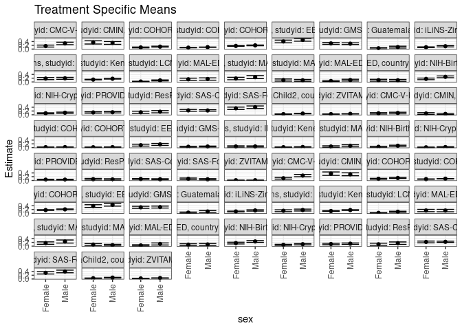

[figure not shown]

[figure not shown]

[figure not shown]

## Results Table

### Parameter: TSM

| agecat | studyid | country | intervention_level | baseline_level | estimate | ci_lower | ci_upper |
| --- | --- | --- | --- | --- | --- | --- | --- |
| 0-24 months | CMC-V-BCS-2002 | INDIA | Female | NA | 0.1604278 | 0.1077559 | 0.2130997 |
| 0-24 months | CMC-V-BCS-2002 | INDIA | Male | NA | 0.3010753 | 0.2350626 | 0.3670879 |
| 0-24 months | CMIN | BANGLADESH | Female | NA | 0.3559322 | 0.2693838 | 0.4424807 |
| 0-24 months | CMIN | BANGLADESH | Male | NA | 0.3267974 | 0.2523384 | 0.4012564 |
| 0-24 months | COHORTS | GUATEMALA | Female | NA | 0.0881890 | 0.0661251 | 0.1102529 |
| 0-24 months | COHORTS | GUATEMALA | Male | NA | 0.1302521 | 0.1055548 | 0.1549494 |
| 0-24 months | COHORTS | INDIA | Female | NA | 0.0763595 | 0.0676216 | 0.0850974 |
| 0-24 months | COHORTS | INDIA | Male | NA | 0.1014794 | 0.0919441 | 0.1110146 |
| 0-24 months | COHORTS | PHILIPPINES | Female | NA | 0.1684137 | 0.1490208 | 0.1878066 |
| 0-24 months | COHORTS | PHILIPPINES | Male | NA | 0.1976456 | 0.1782146 | 0.2170766 |
| 0-24 months | EE | PAKISTAN | Female | NA | 0.4054054 | 0.3345633 | 0.4762475 |
| 0-24 months | EE | PAKISTAN | Male | NA | 0.4896907 | 0.4192541 | 0.5601274 |
| 0-24 months | GMS-Nepal | NEPAL | Female | NA | 0.3012422 | 0.2510937 | 0.3513908 |
| 0-24 months | GMS-Nepal | NEPAL | Male | NA | 0.2884615 | 0.2418861 | 0.3350370 |
| 0-24 months | Guatemala BSC | GUATEMALA | Female | NA | 0.0432099 | 0.0118495 | 0.0745702 |
| 0-24 months | Guatemala BSC | GUATEMALA | Male | NA | 0.1045752 | 0.0560104 | 0.1531400 |
| 0-24 months | iLiNS-Zinc | BURKINA FASO | Female | NA | 0.0972308 | 0.0772323 | 0.1172293 |
| 0-24 months | iLiNS-Zinc | BURKINA FASO | Male | NA | 0.1518293 | 0.1173990 | 0.1862596 |
| 0-24 months | IRC | INDIA | Female | NA | 0.1783784 | 0.1231453 | 0.2336115 |
| 0-24 months | IRC | INDIA | Male | NA | 0.1911111 | 0.1396742 | 0.2425480 |
| 0-24 months | Keneba | GAMBIA | Female | NA | 0.1244666 | 0.1072085 | 0.1417247 |
| 0-24 months | Keneba | GAMBIA | Male | NA | 0.1705375 | 0.1515453 | 0.1895297 |
| 0-24 months | LCNI-5 | MALAWI | Female | NA | 0.0213777 | 0.0075530 | 0.0352023 |
| 0-24 months | LCNI-5 | MALAWI | Male | NA | 0.0811456 | 0.0549845 | 0.1073067 |
| 0-24 months | MAL-ED | BANGLADESH | Female | NA | 0.1417910 | 0.0826153 | 0.2009668 |
| 0-24 months | MAL-ED | BANGLADESH | Male | NA | 0.1550388 | 0.0924611 | 0.2176164 |
| 0-24 months | MAL-ED | INDIA | Female | NA | 0.1811594 | 0.1167713 | 0.2455475 |
| 0-24 months | MAL-ED | INDIA | Male | NA | 0.2566372 | 0.1759442 | 0.3373302 |
| 0-24 months | MAL-ED | NEPAL | Female | NA | 0.1000000 | 0.0438203 | 0.1561797 |
| 0-24 months | MAL-ED | NEPAL | Male | NA | 0.0846154 | 0.0366741 | 0.1325567 |

[output cut: 102 more lines]

### Parameter: E(Y)

| agecat | studyid | country | intervention_level | baseline_level | estimate | ci_lower | ci_upper |
| --- | --- | --- | --- | --- | --- | --- | --- |
| 0-24 months | CMC-V-BCS-2002 | INDIA | NA | NA | 0.2305630 | 0.1877616 | 0.2733644 |
| 0-24 months | CMIN | BANGLADESH | NA | NA | 0.3394834 | 0.2830004 | 0.3959663 |
| 0-24 months | COHORTS | GUATEMALA | NA | NA | 0.1104522 | 0.0937191 | 0.1271852 |
| 0-24 months | COHORTS | INDIA | NA | NA | 0.0894353 | 0.0829338 | 0.0959368 |
| 0-24 months | COHORTS | PHILIPPINES | NA | NA | 0.1839080 | 0.1701456 | 0.1976705 |
| 0-24 months | EE | PAKISTAN | NA | NA | 0.4485488 | 0.3984116 | 0.4986861 |
| 0-24 months | GMS-Nepal | NEPAL | NA | NA | 0.2944606 | 0.2603274 | 0.3285938 |
| 0-24 months | Guatemala BSC | GUATEMALA | NA | NA | 0.0730159 | 0.0442400 | 0.1017917 |
| 0-24 months | iLiNS-Zinc | BURKINA FASO | NA | NA | 0.1246554 | 0.1041227 | 0.1451882 |
| 0-24 months | IRC | INDIA | NA | NA | 0.1853659 | 0.1477057 | 0.2230261 |
| 0-24 months | Keneba | GAMBIA | NA | NA | 0.1483007 | 0.1353925 | 0.1612090 |
| 0-24 months | LCNI-5 | MALAWI | NA | NA | 0.0511905 | 0.0362780 | 0.0661030 |
| 0-24 months | MAL-ED | BANGLADESH | NA | NA | 0.1482890 | 0.1052563 | 0.1913216 |
| 0-24 months | MAL-ED | INDIA | NA | NA | 0.2151394 | 0.1642023 | 0.2660766 |
| 0-24 months | MAL-ED | NEPAL | NA | NA | 0.0916667 | 0.0550838 | 0.1282495 |
| 0-24 months | MAL-ED | SOUTH AFRICA | NA | NA | 0.0737179 | 0.0446760 | 0.1027599 |
| 0-24 months | MAL-ED | TANZANIA, UNITED REPUBLIC OF | NA | NA | 0.0881226 | 0.0536659 | 0.1225793 |
| 0-24 months | NIH-Birth | BANGLADESH | NA | NA | 0.2195513 | 0.1870467 | 0.2520558 |
| 0-24 months | NIH-Crypto | BANGLADESH | NA | NA | 0.0936675 | 0.0729118 | 0.1144233 |
| 0-24 months | PROVIDE | BANGLADESH | NA | NA | 0.1285714 | 0.1037574 | 0.1533855 |
| 0-24 months | ResPak | PAKISTAN | NA | NA | 0.1478873 | 0.1065284 | 0.1892462 |
| 0-24 months | SAS-CompFeed | INDIA | NA | NA | 0.2319894 | 0.1917264 | 0.2722524 |
| 0-24 months | SAS-FoodSuppl | INDIA | NA | NA | 0.3708134 | 0.3244530 | 0.4171738 |
| 0-24 months | TanzaniaChild2 | TANZANIA, UNITED REPUBLIC OF | NA | NA | 0.0496661 | 0.0409652 | 0.0583670 |
| 0-24 months | ZVITAMBO | ZIMBABWE | NA | NA | 0.0423899 | 0.0390454 | 0.0457344 |
| 0-6 months | CMC-V-BCS-2002 | INDIA | NA | NA | 0.0842391 | 0.0558231 | 0.1126551 |
| 0-6 months | CMIN | BANGLADESH | NA | NA | 0.0553506 | 0.0280757 | 0.0826254 |
| 0-6 months | COHORTS | INDIA | NA | NA | 0.0259576 | 0.0222658 | 0.0296495 |
| 0-6 months | COHORTS | PHILIPPINES | NA | NA | 0.0236531 | 0.0182537 | 0.0290525 |
| 0-6 months | EE | PAKISTAN | NA | NA | 0.1503958 | 0.1143605 | 0.1864311 |
| 0-6 months | GMS-Nepal | NEPAL | NA | NA | 0.0524781 | 0.0357793 | 0.0691770 |
| 0-6 months | IRC | INDIA | NA | NA | 0.0611247 | 0.0378797 | 0.0843697 |
| 0-6 months | Keneba | GAMBIA | NA | NA | 0.0284322 | 0.0218657 | 0.0349987 |
| 0-6 months | MAL-ED | INDIA | NA | NA | 0.0756972 | 0.0429084 | 0.1084860 |
| 0-6 months | NIH-Birth | BANGLADESH | NA | NA | 0.0723473 | 0.0519719 | 0.0927227 |
| 0-6 months | NIH-Crypto | BANGLADESH | NA | NA | 0.0224274 | 0.0118796 | 0.0329753 |
| 0-6 months | PROVIDE | BANGLADESH | NA | NA | 0.0428571 | 0.0278427 | 0.0578716 |
| 0-6 months | ResPak | PAKISTAN | NA | NA | 0.0602837 | 0.0324550 | 0.0881124 |
| 0-6 months | SAS-CompFeed | INDIA | NA | NA | 0.0704787 | 0.0478990 | 0.0930584 |
| 0-6 months | SAS-FoodSuppl | INDIA | NA | NA | 0.0769231 | 0.0512858 | 0.1025603 |
| 0-6 months | ZVITAMBO | ZIMBABWE | NA | NA | 0.0120612 | 0.0102430 | 0.0138795 |
| 6-24 months | CMC-V-BCS-2002 | INDIA | NA | NA | 0.1876676 | 0.1479906 | 0.2273445 |
| 6-24 months | CMIN | BANGLADESH | NA | NA | 0.3426295 | 0.2837999 | 0.4014590 |
| 6-24 months | COHORTS | GUATEMALA | NA | NA | 0.1116585 | 0.0939639 | 0.1293530 |
| 6-24 months | COHORTS | INDIA | NA | NA | 0.0831652 | 0.0766672 | 0.0896632 |
| 6-24 months | COHORTS | PHILIPPINES | NA | NA | 0.1908832 | 0.1763448 | 0.2054216 |
| 6-24 months | EE | PAKISTAN | NA | NA | 0.4193548 | 0.3691429 | 0.4695668 |
| 6-24 months | GMS-Nepal | NEPAL | NA | NA | 0.3254237 | 0.2875855 | 0.3632619 |
| 6-24 months | Guatemala BSC | GUATEMALA | NA | NA | 0.0649819 | 0.0359016 | 0.0940623 |
| 6-24 months | iLiNS-Zinc | BURKINA FASO | NA | NA | 0.1246554 | 0.1041227 | 0.1451882 |
| 6-24 months | IRC | INDIA | NA | NA | 0.1560976 | 0.1209228 | 0.1912723 |
| 6-24 months | Keneba | GAMBIA | NA | NA | 0.1469835 | 0.1337108 | 0.1602563 |
| 6-24 months | LCNI-5 | MALAWI | NA | NA | 0.0520581 | 0.0368996 | 0.0672166 |
| 6-24 months | MAL-ED | BANGLADESH | NA | NA | 0.1464435 | 0.1015265 | 0.1913605 |
| 6-24 months | MAL-ED | INDIA | NA | NA | 0.2000000 | 0.1487493 | 0.2512507 |
| 6-24 months | MAL-ED | NEPAL | NA | NA | 0.0680851 | 0.0358110 | 0.1003592 |
| 6-24 months | MAL-ED | SOUTH AFRICA | NA | NA | 0.0772201 | 0.0446475 | 0.1097927 |
| 6-24 months | MAL-ED | TANZANIA, UNITED REPUBLIC OF | NA | NA | 0.0857143 | 0.0505889 | 0.1208396 |
| 6-24 months | NIH-Birth | BANGLADESH | NA | NA | 0.2103321 | 0.1759902 | 0.2446740 |
| 6-24 months | NIH-Crypto | BANGLADESH | NA | NA | 0.0863014 | 0.0659171 | 0.1066856 |
| 6-24 months | PROVIDE | BANGLADESH | NA | NA | 0.1221498 | 0.0962275 | 0.1480722 |
| 6-24 months | ResPak | PAKISTAN | NA | NA | 0.1313559 | 0.0881682 | 0.1745436 |
| 6-24 months | SAS-CompFeed | INDIA | NA | NA | 0.2260619 | 0.1909133 | 0.2612105 |
| 6-24 months | SAS-FoodSuppl | INDIA | NA | NA | 0.3615960 | 0.3145115 | 0.4086805 |
| 6-24 months | TanzaniaChild2 | TANZANIA, UNITED REPUBLIC OF | NA | NA | 0.0560238 | 0.0459853 | 0.0660623 |
| 6-24 months | ZVITAMBO | ZIMBABWE | NA | NA | 0.0410617 | 0.0373214 | 0.0448020 |

### Parameter: RR

| agecat | studyid | country | intervention_level | baseline_level | estimate | ci_lower | ci_upper |
| --- | --- | --- | --- | --- | --- | --- | --- |
| 0-24 months | CMC-V-BCS-2002 | INDIA | Female | Female | 1.0000000 | 1.0000000 | 1.000000 |
| 0-24 months | CMC-V-BCS-2002 | INDIA | Male | Female | 1.8767025 | 1.2645477 | 2.785195 |
| 0-24 months | CMIN | BANGLADESH | Female | Female | 1.0000000 | 1.0000000 | 1.000000 |
| 0-24 months | CMIN | BANGLADESH | Male | Female | 0.9181450 | 0.6579499 | 1.281238 |
| 0-24 months | COHORTS | GUATEMALA | Female | Female | 1.0000000 | 1.0000000 | 1.000000 |
| 0-24 months | COHORTS | GUATEMALA | Male | Female | 1.4769658 | 1.0790361 | 2.021645 |
| 0-24 months | COHORTS | INDIA | Female | Female | 1.0000000 | 1.0000000 | 1.000000 |
| 0-24 months | COHORTS | INDIA | Male | Female | 1.3289678 | 1.1460682 | 1.541056 |
| 0-24 months | COHORTS | PHILIPPINES | Female | Female | 1.0000000 | 1.0000000 | 1.000000 |
| 0-24 months | COHORTS | PHILIPPINES | Male | Female | 1.1735720 | 1.0086800 | 1.365419 |
| 0-24 months | EE | PAKISTAN | Female | Female | 1.0000000 | 1.0000000 | 1.000000 |
| 0-24 months | EE | PAKISTAN | Male | Female | 1.2079038 | 0.9632493 | 1.514698 |
| 0-24 months | GMS-Nepal | NEPAL | Female | Female | 1.0000000 | 1.0000000 | 1.000000 |
| 0-24 months | GMS-Nepal | NEPAL | Male | Female | 0.9575734 | 0.7593713 | 1.207508 |
| 0-24 months | Guatemala BSC | GUATEMALA | Female | Female | 1.0000000 | 1.0000000 | 1.000000 |
| 0-24 months | Guatemala BSC | GUATEMALA | Male | Female | 2.4201681 | 1.0224546 | 5.728580 |
| 0-24 months | iLiNS-Zinc | BURKINA FASO | Female | Female | 1.0000000 | 1.0000000 | 1.000000 |
| 0-24 months | iLiNS-Zinc | BURKINA FASO | Male | Female | 1.5615352 | 1.1747233 | 2.075716 |
| 0-24 months | IRC | INDIA | Female | Female | 1.0000000 | 1.0000000 | 1.000000 |
| 0-24 months | IRC | INDIA | Male | Female | 1.0713805 | 0.7108340 | 1.614802 |
| 0-24 months | Keneba | GAMBIA | Female | Female | 1.0000000 | 1.0000000 | 1.000000 |
| 0-24 months | Keneba | GAMBIA | Male | Female | 1.3701469 | 1.1469143 | 1.636829 |
| 0-24 months | LCNI-5 | MALAWI | Female | Female | 1.0000000 | 1.0000000 | 1.000000 |
| 0-24 months | LCNI-5 | MALAWI | Male | Female | 3.7958101 | 1.8428332 | 7.818491 |
| 0-24 months | MAL-ED | BANGLADESH | Female | Female | 1.0000000 | 1.0000000 | 1.000000 |
| 0-24 months | MAL-ED | BANGLADESH | Male | Female | 1.0934313 | 0.6118463 | 1.954072 |
| 0-24 months | MAL-ED | INDIA | Female | Female | 1.0000000 | 1.0000000 | 1.000000 |
| 0-24 months | MAL-ED | INDIA | Male | Female | 1.4166372 | 0.8813913 | 2.276924 |
| 0-24 months | MAL-ED | NEPAL | Female | Female | 1.0000000 | 1.0000000 | 1.000000 |
| 0-24 months | MAL-ED | NEPAL | Male | Female | 0.8461538 | 0.3810047 | 1.879180 |

[output cut: 102 more lines]

### Parameter: PAR

| agecat | studyid | country | intervention_level | baseline_level | estimate | ci_lower | ci_upper |
| --- | --- | --- | --- | --- | --- | --- | --- |
| 0-24 months | CMC-V-BCS-2002 | INDIA | Female | NA | 0.0701352 | 0.0274208 | 0.1128496 |
| 0-24 months | CMIN | BANGLADESH | Female | NA | -0.0164488 | -0.0809294 | 0.0480318 |
| 0-24 months | COHORTS | GUATEMALA | Female | NA | 0.0222632 | 0.0046989 | 0.0398275 |
| 0-24 months | COHORTS | INDIA | Female | NA | 0.0130757 | 0.0063374 | 0.0198141 |
| 0-24 months | COHORTS | PHILIPPINES | Female | NA | 0.0154943 | 0.0009339 | 0.0300548 |
| 0-24 months | EE | PAKISTAN | Female | NA | 0.0431434 | -0.0081686 | 0.0944554 |
| 0-24 months | GMS-Nepal | NEPAL | Female | NA | -0.0067816 | -0.0431003 | 0.0295371 |
| 0-24 months | Guatemala BSC | GUATEMALA | Female | NA | 0.0298060 | 0.0015226 | 0.0580894 |
| 0-24 months | iLiNS-Zinc | BURKINA FASO | Female | NA | 0.0274247 | 0.0094190 | 0.0454303 |
| 0-24 months | IRC | INDIA | Female | NA | 0.0069875 | -0.0344362 | 0.0484111 |
| 0-24 months | Keneba | GAMBIA | Female | NA | 0.0238341 | 0.0105319 | 0.0371364 |
| 0-24 months | LCNI-5 | MALAWI | Female | NA | 0.0298128 | 0.0149155 | 0.0447101 |
| 0-24 months | MAL-ED | BANGLADESH | Female | NA | 0.0064979 | -0.0357541 | 0.0487500 |
| 0-24 months | MAL-ED | INDIA | Female | NA | 0.0339800 | -0.0127282 | 0.0806883 |
| 0-24 months | MAL-ED | NEPAL | Female | NA | -0.0083333 | -0.0483498 | 0.0316831 |
| 0-24 months | MAL-ED | SOUTH AFRICA | Female | NA | 0.0230850 | -0.0056970 | 0.0518671 |
| 0-24 months | MAL-ED | TANZANIA, UNITED REPUBLIC OF | Female | NA | -0.0027865 | -0.0368381 | 0.0312651 |
| 0-24 months | NIH-Birth | BANGLADESH | Female | NA | 0.0573891 | 0.0235200 | 0.0912582 |
| 0-24 months | NIH-Crypto | BANGLADESH | Female | NA | 0.0149274 | -0.0057351 | 0.0355898 |
| 0-24 months | PROVIDE | BANGLADESH | Female | NA | 0.0050775 | -0.0210040 | 0.0311589 |
| 0-24 months | ResPak | PAKISTAN | Female | NA | 0.0155344 | -0.0274551 | 0.0585239 |
| 0-24 months | SAS-CompFeed | INDIA | Female | NA | -0.0027045 | -0.0211624 | 0.0157535 |
| 0-24 months | SAS-FoodSuppl | INDIA | Female | NA | 0.0255219 | -0.0179270 | 0.0689708 |
| 0-24 months | TanzaniaChild2 | TANZANIA, UNITED REPUBLIC OF | Female | NA | 0.0141931 | 0.0054180 | 0.0229683 |
| 0-24 months | ZVITAMBO | ZIMBABWE | Female | NA | 0.0072504 | 0.0038252 | 0.0106755 |
| 0-6 months | CMC-V-BCS-2002 | INDIA | Female | NA | 0.0085635 | -0.0197129 | 0.0368398 |
| 0-6 months | CMIN | BANGLADESH | Female | NA | -0.0124461 | -0.0442364 | 0.0193443 |
| 0-6 months | COHORTS | INDIA | Female | NA | 0.0019414 | -0.0018554 | 0.0057383 |
| 0-6 months | COHORTS | PHILIPPINES | Female | NA | 0.0033875 | -0.0022994 | 0.0090745 |
| 0-6 months | EE | PAKISTAN | Female | NA | 0.0206660 | -0.0161356 | 0.0574677 |
| 0-6 months | GMS-Nepal | NEPAL | Female | NA | 0.0058943 | -0.0117505 | 0.0235391 |
| 0-6 months | IRC | INDIA | Female | NA | 0.0013421 | -0.0243144 | 0.0269986 |
| 0-6 months | Keneba | GAMBIA | Female | NA | 0.0056088 | -0.0011694 | 0.0123870 |
| 0-6 months | MAL-ED | INDIA | Female | NA | 0.0177262 | -0.0126561 | 0.0481085 |
| 0-6 months | NIH-Birth | BANGLADESH | Female | NA | 0.0282795 | 0.0072218 | 0.0493371 |
| 0-6 months | NIH-Crypto | BANGLADESH | Female | NA | 0.0066794 | -0.0038292 | 0.0171881 |
| 0-6 months | PROVIDE | BANGLADESH | Female | NA | 0.0006885 | -0.0151072 | 0.0164841 |
| 0-6 months | ResPak | PAKISTAN | Female | NA | -0.0058928 | -0.0348161 | 0.0230305 |
| 0-6 months | SAS-CompFeed | INDIA | Female | NA | -0.0085842 | -0.0195386 | 0.0023702 |
| 0-6 months | SAS-FoodSuppl | INDIA | Female | NA | -0.0131670 | -0.0368644 | 0.0105303 |
| 0-6 months | ZVITAMBO | ZIMBABWE | Female | NA | 0.0004472 | -0.0014243 | 0.0023187 |
| 6-24 months | CMC-V-BCS-2002 | INDIA | Female | NA | 0.0700205 | 0.0304159 | 0.1096251 |
| 6-24 months | CMIN | BANGLADESH | Female | NA | -0.0184816 | -0.0863770 | 0.0494137 |
| 6-24 months | COHORTS | GUATEMALA | Female | NA | 0.0224646 | 0.0041352 | 0.0407941 |
| 6-24 months | COHORTS | INDIA | Female | NA | 0.0108978 | 0.0041500 | 0.0176456 |
| 6-24 months | COHORTS | PHILIPPINES | Female | NA | 0.0193256 | 0.0040509 | 0.0346004 |
| 6-24 months | EE | PAKISTAN | Female | NA | 0.0347395 | -0.0165340 | 0.0860129 |
| 6-24 months | GMS-Nepal | NEPAL | Female | NA | 0.0061255 | -0.0330051 | 0.0452561 |
| 6-24 months | Guatemala BSC | GUATEMALA | Female | NA | 0.0297707 | 0.0010939 | 0.0584475 |
| 6-24 months | iLiNS-Zinc | BURKINA FASO | Female | NA | 0.0274247 | 0.0094190 | 0.0454303 |
| 6-24 months | IRC | INDIA | Female | NA | 0.0209624 | -0.0174382 | 0.0593630 |
| 6-24 months | Keneba | GAMBIA | Female | NA | 0.0261376 | 0.0125003 | 0.0397749 |
| 6-24 months | LCNI-5 | MALAWI | Female | NA | 0.0304754 | 0.0153792 | 0.0455715 |
| 6-24 months | MAL-ED | BANGLADESH | Female | NA | -0.0010975 | -0.0450786 | 0.0428837 |
| 6-24 months | MAL-ED | INDIA | Female | NA | 0.0372093 | -0.0099894 | 0.0844081 |
| 6-24 months | MAL-ED | NEPAL | Female | NA | -0.0144837 | -0.0496344 | 0.0206670 |
| 6-24 months | MAL-ED | SOUTH AFRICA | Female | NA | 0.0384604 | 0.0058218 | 0.0710989 |
| 6-24 months | MAL-ED | TANZANIA, UNITED REPUBLIC OF | Female | NA | 0.0050691 | -0.0296519 | 0.0397902 |
| 6-24 months | NIH-Birth | BANGLADESH | Female | NA | 0.0477305 | 0.0106376 | 0.0848233 |
| 6-24 months | NIH-Crypto | BANGLADESH | Female | NA | 0.0158407 | -0.0043592 | 0.0360405 |
| 6-24 months | PROVIDE | BANGLADESH | Female | NA | 0.0099049 | -0.0170616 | 0.0368714 |
| 6-24 months | ResPak | PAKISTAN | Female | NA | 0.0313559 | -0.0142420 | 0.0769538 |
| 6-24 months | SAS-CompFeed | INDIA | Female | NA | 0.0033055 | -0.0150769 | 0.0216879 |
| 6-24 months | SAS-FoodSuppl | INDIA | Female | NA | 0.0345818 | -0.0102133 | 0.0793768 |
| 6-24 months | TanzaniaChild2 | TANZANIA, UNITED REPUBLIC OF | Female | NA | 0.0159034 | 0.0057810 | 0.0260259 |
| 6-24 months | ZVITAMBO | ZIMBABWE | Female | NA | 0.0101377 | 0.0063770 | 0.0138984 |

### Parameter: PAF

| agecat | studyid | country | intervention_level | baseline_level | estimate | ci_lower | ci_upper |
| --- | --- | --- | --- | --- | --- | --- | --- |
| 0-24 months | CMC-V-BCS-2002 | INDIA | Female | NA | 0.3041910 | 0.0985387 | 0.4629274 |
| 0-24 months | CMIN | BANGLADESH | Female | NA | -0.0484525 | -0.2566981 | 0.1252851 |
| 0-24 months | COHORTS | GUATEMALA | Female | NA | 0.2015642 | 0.0284869 | 0.3438075 |
| 0-24 months | COHORTS | INDIA | Female | NA | 0.1462035 | 0.0681202 | 0.2177441 |
| 0-24 months | COHORTS | PHILIPPINES | Female | NA | 0.0842505 | 0.0017156 | 0.1599617 |
| 0-24 months | EE | PAKISTAN | Female | NA | 0.0961844 | -0.0260354 | 0.2038456 |
| 0-24 months | GMS-Nepal | NEPAL | Female | NA | -0.0230306 | -0.1541087 | 0.0931603 |
| 0-24 months | Guatemala BSC | GUATEMALA | Female | NA | 0.4082126 | -0.0795945 | 0.6756075 |
| 0-24 months | iLiNS-Zinc | BURKINA FASO | Female | NA | 0.2200038 | 0.0768226 | 0.3409781 |
| 0-24 months | IRC | INDIA | Female | NA | 0.0376956 | -0.2137593 | 0.2370565 |
| 0-24 months | Keneba | GAMBIA | Female | NA | 0.1607150 | 0.0669111 | 0.2450888 |
| 0-24 months | LCNI-5 | MALAWI | Female | NA | 0.5823897 | 0.2595443 | 0.7644715 |
| 0-24 months | MAL-ED | BANGLADESH | Female | NA | 0.0438194 | -0.2878596 | 0.2900768 |
| 0-24 months | MAL-ED | INDIA | Female | NA | 0.1579442 | -0.0874692 | 0.3479741 |
| 0-24 months | MAL-ED | NEPAL | Female | NA | -0.0909091 | -0.6259577 | 0.2680728 |
| 0-24 months | MAL-ED | SOUTH AFRICA | Female | NA | 0.3131535 | -0.1816790 | 0.6007731 |
| 0-24 months | MAL-ED | TANZANIA, UNITED REPUBLIC OF | Female | NA | -0.0316206 | -0.5001196 | 0.2905626 |
| 0-24 months | NIH-Birth | BANGLADESH | Female | NA | 0.2613928 | 0.0933570 | 0.3982850 |
| 0-24 months | NIH-Crypto | BANGLADESH | Female | NA | 0.1593656 | -0.0898297 | 0.3515812 |
| 0-24 months | PROVIDE | BANGLADESH | Female | NA | 0.0394913 | -0.1862497 | 0.2222742 |
| 0-24 months | ResPak | PAKISTAN | Female | NA | 0.1050420 | -0.2369958 | 0.3525040 |
| 0-24 months | SAS-CompFeed | INDIA | Female | NA | -0.0116577 | -0.0938540 | 0.0643621 |
| 0-24 months | SAS-FoodSuppl | INDIA | Female | NA | 0.0688268 | -0.0560711 | 0.1789536 |
| 0-24 months | TanzaniaChild2 | TANZANIA, UNITED REPUBLIC OF | Female | NA | 0.2857711 | 0.0938431 | 0.4370479 |
| 0-24 months | ZVITAMBO | ZIMBABWE | Female | NA | 0.1710402 | 0.0873278 | 0.2470743 |
| 0-6 months | CMC-V-BCS-2002 | INDIA | Female | NA | 0.1016565 | -0.3031943 | 0.3807362 |
| 0-6 months | CMIN | BANGLADESH | Female | NA | -0.2248588 | -0.9429342 | 0.2278282 |
| 0-6 months | COHORTS | INDIA | Female | NA | 0.0747920 | -0.0832440 | 0.2097719 |
| 0-6 months | COHORTS | PHILIPPINES | Female | NA | 0.1432176 | -0.1315075 | 0.3512407 |
| 0-6 months | EE | PAKISTAN | Female | NA | 0.1374111 | -0.1434763 | 0.3493004 |
| 0-6 months | GMS-Nepal | NEPAL | Female | NA | 0.1123188 | -0.2939481 | 0.3910283 |
| 0-6 months | IRC | INDIA | Female | NA | 0.0219565 | -0.5021362 | 0.3631942 |
| 0-6 months | Keneba | GAMBIA | Female | NA | 0.1972709 | -0.0746909 | 0.4004099 |
| 0-6 months | MAL-ED | INDIA | Female | NA | 0.2341724 | -0.2743674 | 0.5397780 |
| 0-6 months | NIH-Birth | BANGLADESH | Female | NA | 0.3908851 | 0.0486800 | 0.6099936 |
| 0-6 months | NIH-Crypto | BANGLADESH | Female | NA | 0.2978231 | -0.3287277 | 0.6289289 |
| 0-6 months | PROVIDE | BANGLADESH | Female | NA | 0.0160643 | -0.4309641 | 0.3234424 |
| 0-6 months | ResPak | PAKISTAN | Female | NA | -0.0977509 | -0.6966611 | 0.2897480 |
| 0-6 months | SAS-CompFeed | INDIA | Female | NA | -0.1217989 | -0.3112883 | 0.0403080 |
| 0-6 months | SAS-FoodSuppl | INDIA | Female | NA | -0.1711712 | -0.5179939 | 0.0964114 |
| 0-6 months | ZVITAMBO | ZIMBABWE | Female | NA | 0.0370765 | -0.1311756 | 0.1803027 |
| 6-24 months | CMC-V-BCS-2002 | INDIA | Female | NA | 0.3731092 | 0.1371252 | 0.5445550 |
| 6-24 months | CMIN | BANGLADESH | Female | NA | -0.0539406 | -0.2719792 | 0.1267226 |
| 6-24 months | COHORTS | GUATEMALA | Female | NA | 0.2011906 | 0.0220075 | 0.3475446 |
| 6-24 months | COHORTS | INDIA | Female | NA | 0.1310379 | 0.0465910 | 0.2080050 |
| 6-24 months | COHORTS | PHILIPPINES | Female | NA | 0.1012432 | 0.0177855 | 0.1776096 |
| 6-24 months | EE | PAKISTAN | Female | NA | 0.0828402 | -0.0481008 | 0.1974226 |
| 6-24 months | GMS-Nepal | NEPAL | Female | NA | 0.0188231 | -0.1090995 | 0.1319912 |
| 6-24 months | Guatemala BSC | GUATEMALA | Female | NA | 0.4581377 | -0.1228692 | 0.7385139 |
| 6-24 months | iLiNS-Zinc | BURKINA FASO | Female | NA | 0.2200038 | 0.0768226 | 0.3409781 |
| 6-24 months | IRC | INDIA | Female | NA | 0.1342905 | -0.1485419 | 0.3474745 |
| 6-24 months | Keneba | GAMBIA | Female | NA | 0.1778269 | 0.0807283 | 0.2646694 |
| 6-24 months | LCNI-5 | MALAWI | Female | NA | 0.5854107 | 0.2649791 | 0.7661505 |
| 6-24 months | MAL-ED | BANGLADESH | Female | NA | -0.0074941 | -0.3573778 | 0.2522020 |
| 6-24 months | MAL-ED | INDIA | Female | NA | 0.1860465 | -0.0838864 | 0.3887549 |
| 6-24 months | MAL-ED | NEPAL | Female | NA | -0.2127294 | -0.8438437 | 0.2023660 |
| 6-24 months | MAL-ED | SOUTH AFRICA | Female | NA | 0.4980620 | -0.0527516 | 0.7606826 |
| 6-24 months | MAL-ED | TANZANIA, UNITED REPUBLIC OF | Female | NA | 0.0591398 | -0.4462082 | 0.3879042 |
| 6-24 months | NIH-Birth | BANGLADESH | Female | NA | 0.2269291 | 0.0317300 | 0.3827769 |
| 6-24 months | NIH-Crypto | BANGLADESH | Female | NA | 0.1835506 | -0.0829649 | 0.3844771 |
| 6-24 months | PROVIDE | BANGLADESH | Female | NA | 0.0810884 | -0.1678188 | 0.2769439 |
| 6-24 months | ResPak | PAKISTAN | Female | NA | 0.2387097 | -0.1902669 | 0.5130815 |
| 6-24 months | SAS-CompFeed | INDIA | Female | NA | 0.0146221 | -0.0711514 | 0.0935272 |
| 6-24 months | SAS-FoodSuppl | INDIA | Female | NA | 0.0956365 | -0.0371483 | 0.2114211 |
| 6-24 months | TanzaniaChild2 | TANZANIA, UNITED REPUBLIC OF | Female | NA | 0.2838693 | 0.0868997 | 0.4383496 |
| 6-24 months | ZVITAMBO | ZIMBABWE | Female | NA | 0.2468893 | 0.1524557 | 0.3308011 |